# Lecture 10

Multivariate Regression

Prior to this lecture, you should have read chapter 10 of [Regression and Other Stories](https://users.aalto.fi/~ave/ROS.pdf).

## Example data

Five hundred students enrolled in a course. Students were randomly assigned to one of three instructors. Students took a pretest at the beginning of the term to test their initial knowledge of the topic. Prior to taking the final exam, students were asked how much time they spent studying for the course each week.

Here is a scatter plot showing the relationship to students’ pretest scores and their scores on the final exam:

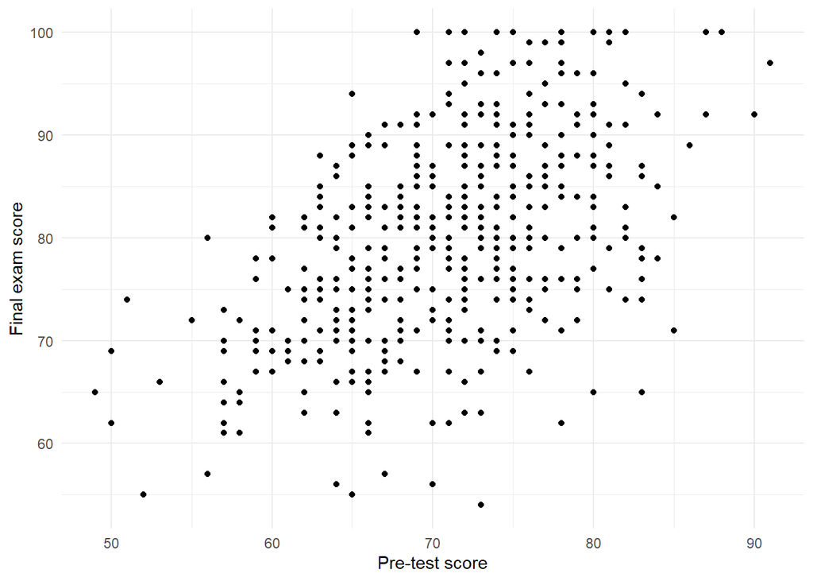

Here is a scatter plot showing the relationship between the amount of time students spent studying and their scores on the final exam:

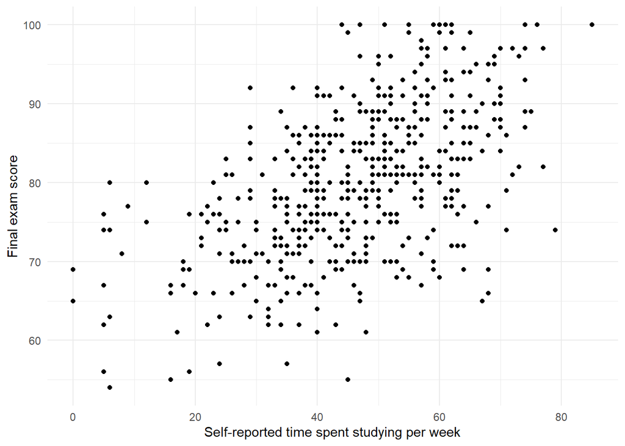

Here are the student scores for each instructor, with average values indicated by horizonal lines.

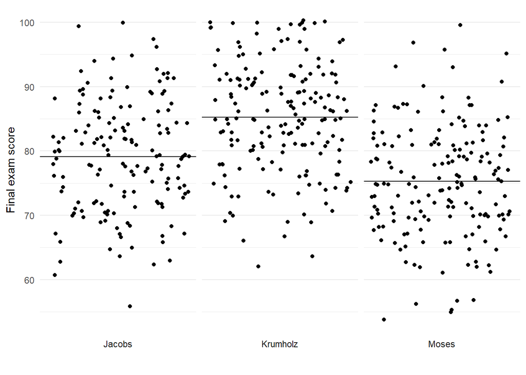

Higher test scores seem to be associated with more time spent studying, higher pretest scores, and with being in Krumholz’s class.

## Estimating a multiple regression model

Let’s predict final exam scores based on pretest scores, weekly time spent studying, and instructor.

[figure not shown]

```r
model <- lm(final_score ~ pretest + time_studying + instructor,
            data = exam_data)
```

You’ll get the same results in R as in Excel:

```r
summary(model)
```

```
##
## Call:
## lm(formula = final_score ~ pretest + time_studying + instructor,
##     data = exam_data)
##
## Residuals:
##     Min      1Q  Median      3Q     Max
## -11.348  -2.549  -0.065   2.498  11.137
##
## Coefficients:
##                    Estimate Std. Error t value Pr(>|t|)
## (Intercept)         3.00337    1.96480   1.529    0.127
## pretest             0.82064    0.02535  32.371  < 2e-16 ***
## time_studying       0.38154    0.01160  32.901  < 2e-16 ***
## instructorKrumholz  6.67970    0.43271  15.437  < 2e-16 ***
## instructorMoses    -3.29995    0.43356  -7.611 1.38e-13 ***
## ---
## Signif. codes:  0 '***' 0.001 '**' 0.01 '*' 0.05 '.' 0.1 ' ' 1
##
## Residual standard error: 3.906 on 495 degrees of freedom
## Multiple R-squared:  0.8347, Adjusted R-squared:  0.8334
## F-statistic: 625.1 on 4 and 495 DF,  p-value: < 2.2e-16
```

[figure not shown]

Each coefficient represents the change in the outcome (test score) that would be predicted based on a one-unit change in the associated predictor, **if all other variables in the model were held constant**.